# 1. library Preparation

```python
### Basic libraries

import numpy as np
import pandas as pd
import matplotlib.pyplot as plt
import seaborn as sns

% matplotlib inline
# Always make it pretty.
plt.style.use('ggplot')

import time
```

```python
### imbalance learn library

from imblearn.pipeline import Pipeline
from imblearn.under_sampling import RandomUnderSampler, NearMiss
from imblearn.over_sampling import SMOTE
from imblearn.combine import SMOTEENN

## warnings occur at the resampling method: "SMOTEENN"
# import warnings
# warnings.filterwarnings("ignore")
```

```python
### sklearn machine learning library

from sklearn.metrics import make_scorer, roc_curve, auc

# Import metrics functions from sklearn
from sklearn.metrics import precision_score, accuracy_score, recall_score, f1_score, roc_auc_score, \
                            precision_recall_curve, average_precision_score, confusion_matrix

# gonna use 5 models
from sklearn.linear_model import LogisticRegression
from sklearn.ensemble import RandomForestClassifier, AdaBoostClassifier, GradientBoostingClassifier
from sklearn.svm import SVC
from xgboost import XGBClassifier

from sklearn.model_selection import train_test_split, GridSearchCV, StratifiedKFold, cross_val_score
```

```python
### Import H2O and initial an H2O instance.

# import h2o
# # help(h2o.init)
# h2o.init(nthreads=7, min_mem_size=15, max_mem_size=20)
```

```python
# h2o.cluster().shutdown()
```

# 2. Loading Data

Read the data generated in Rstudio by "data.table" from local.

```python
df = pd.read_csv('loanStat2017Q1_model_2nd.csv')
```

```python
print(df.head())
print(df.iloc[:, :15].info())
```

```
   loanStatus lastPymntFromIssueCat nextPymntFromIssueCat  \
0           0             (366,457]             (366,457]
1           0             (366,457]             (366,457]
2           0             (366,457]             (366,457]
3           1             (275,366]             (275,366]
4           0                (0,92]                (0,92]

   mthsLastCreditPullSinceIssue mthsHardshipFromIssue mthsSettlementFromIssue  \
0                            14           no_hardship           no_settlement
1                            14           no_hardship           no_settlement
2                            13           no_hardship           no_settlement
3                            12           no_hardship           no_settlement
4                             1           no_hardship           no_settlement

   mthsHardshipLength grade        term yrsEmpLengthCat    ...      \
0                   0     C   36 months              >9    ...
1                   0     B   36 months           (6,9]    ...
2                   0     A   36 months           (3,6]    ...
3                   0     D   36 months              >9    ...
4                   0     E   60 months              >9    ...

  num_actv_rev_tl num_bc_tl num_il_tl  num_op_rev_tl num_rev_tl_bal_gt_0  \
0               4         5         9              4                   4
1               5         5         2              9                   5
2               7         6        14              8                   7
3               2         4         5              2                   2
4              13        13         4             16                  13

  num_tl_90g_dpd_24m num_tl_op_past_12m pct_tl_nvr_dlq  pub_rec_bankruptcies  \
0                  0                  2          100.0                     1
1                  0                  1           94.7                     0
2                  0                  2           95.0                     0
3                  1                  1           83.3                     0
4                  0                  1          100.0                     0

   tax_liens
0          0
1          1
2          0
3          0
```

[output cut: 9 more lines]

```
mthsLastCreditPullSinceIssue    96779 non-null int64
mthsHardshipFromIssue           96779 non-null object
mthsSettlementFromIssue         96779 non-null object
mthsHardshipLength              96779 non-null int64
grade                           96779 non-null object
term                            96779 non-null object
yrsEmpLengthCat                 96779 non-null object
home_ownership                  96779 non-null object
addrStateCat                    96779 non-null object
zipCodeCat                      96779 non-null object
verificationStatus              96779 non-null int64
pymnt_plan                      96779 non-null object
dtypes: int64(4), object(11)
memory usage: 11.1+ MB
None
```

```python
## extract names of all object columns
catCols1 = df.select_dtypes(include='object').columns.tolist()
```

```python
# Change numeric columns with no greater than 3 unique values to categorical

df_nuniqueInt = df.select_dtypes(include='int').apply(lambda x: x.nunique())
num2cat = df_nuniqueInt[df_nuniqueInt <= 3].index.tolist()
num2cat.remove('loanStatus')

for col in num2cat:
    df[col] = df[col].astype('object')
```

```python
numcols = [e for e in df.columns.tolist() if e not in (catCols1 + num2cat)]
print(numcols)
```

```
['loanStatus', 'mthsLastCreditPullSinceIssue', 'mthsHardshipLength', 'mthsFromEarliestCrLineToIssue', 'annualInclog10', 'dti', 'inqLast6mths', 'mortAcc', 'collections12MthsExMed', 'hsAmount', 'hsDpd', 'hsPayoffBalanceAmount', 'hsLastPaymentAmount', 'smAmount', 'smPercentage', 'smTerm', 'allUtil', 'o…
```

```python
df[numcols].filter(regex='_').describe()
```

|  | delinq_2yrs | pub_rec | total_rec_late_fee | open_acc_6m | open_il_12m | open_il_24m | open_rv_12m | open_rv_24m | inq_fi | total_cu_tl | ... | num_actv_rev_tl | num_bc_tl | num_il_tl | num_op_rev_tl | num_rev_tl_bal_gt_0 | num_tl_90g_dpd_24m | num_tl_op_past_12m | pct_tl_nvr_dlq | pub_rec_bankruptcies | tax_liens |
| --- | --- | --- | --- | --- | --- | --- | --- | --- | --- | --- | --- | --- | --- | --- | --- | --- | --- | --- | --- | --- | --- |
| count | 96779.000000 | 96779.000000 | 9.677900e+04 | 96779.000000 | 96779.000000 | 96779.000000 | 96779.000000 | 96779.000000 | 96779.000000 | 96779.000000 | ... | 96779.000000 | 96779.000000 | 96779.000000 | 96779.000000 | 96779.000000 | 96779.000000 | 96779.000000 | 96779.000000 | 96779.000000 | 96779.000000 |
| mean | 0.349642 | 0.266318 | 8.878915e-01 | 0.917327 | 0.605317 | 1.521105 | 1.301026 | 2.764122 | 0.931803 | 1.460368 | ... | 5.738022 | 7.508003 | 8.444911 | 8.300189 | 5.652838 | 0.089927 | 2.049804 | 93.581718 | 0.144577 | 0.081350 |
| std | 0.929675 | 0.716462 | 7.977796e+00 | 1.120670 | 0.830715 | 1.486059 | 1.499816 | 2.589798 | 1.435166 | 2.671873 | ... | 3.447396 | 4.579339 | 7.358304 | 4.768307 | 3.319023 | 0.519021 | 1.825857 | 9.517363 | 0.396557 | 0.520256 |
| min | 0.000000 | 0.000000 | -4.000000e-10 | 0.000000 | 0.000000 | 0.000000 | 0.000000 | 0.000000 | 0.000000 | 0.000000 | ... | 0.000000 | 0.000000 | 0.000000 | 0.000000 | 0.000000 | 0.000000 | 0.000000 | 5.900000 | 0.000000 | 0.000000 |
| 25% | 0.000000 | 0.000000 | 0.000000e+00 | 0.000000 | 0.000000 | 0.000000 | 0.000000 | 1.000000 | 0.000000 | 0.000000 | ... | 3.000000 | 4.000000 | 3.000000 | 5.000000 | 3.000000 | 0.000000 | 1.000000 | 90.500000 | 0.000000 | 0.000000 |
| 50% | 0.000000 | 0.000000 | 0.000000e+00 | 1.000000 | 0.000000 | 1.000000 | 1.000000 | 2.000000 | 0.000000 | 0.000000 | ... | 5.000000 | 7.000000 | 6.000000 | 7.000000 | 5.000000 | 0.000000 | 2.000000 | 97.300000 | 0.000000 | 0.000000 |
| 75% | 0.000000 | 0.000000 | 0.000000e+00 | 1.000000 | 1.000000 | 2.000000 | 2.000000 | 4.000000 | 1.000000 | 2.000000 | ... | 7.000000 | 10.000000 | 11.000000 | 11.000000 | 7.000000 | 0.000000 | 3.000000 | 100.000000 | 0.000000 | 0.000000 |
| max | 21.000000 | 61.000000 | 4.366600e+02 | 14.000000 | 11.000000 | 22.000000 | 28.000000 | 54.000000 | 25.000000 | 68.000000 | ... | 44.000000 | 64.000000 | 109.000000 | 69.000000 | 41.000000 | 19.000000 | 28.000000 | 100.000000 | 7.000000 | 61.000000 |

8 rows × 23 columns

##### Since the data has been cleansed in R-studio. We just have to one-hot encode all categorical features.

```python
catCols = catCols1 + num2cat
print(catCols)
```

```
['lastPymntFromIssueCat', 'nextPymntFromIssueCat', 'mthsHardshipFromIssue', 'mthsSettlementFromIssue', 'grade', 'term', 'yrsEmpLengthCat', 'home_ownership', 'addrStateCat', 'zipCodeCat', 'pymnt_plan', 'purpose', 'title', 'initial_list_status', 'debt_settlement_flag', 'settlementStatus', 'mthsSinceLa…
```

```python
df_dummies = pd.get_dummies(df, columns=catCols)
df_dummies.info()
```

```
<class 'pandas.core.frame.DataFrame'>
RangeIndex: 96779 entries, 0 to 96778
Columns: 229 entries, loanStatus to hsLength_3
dtypes: float64(30), int64(31), uint8(168)
memory usage: 60.5 MB
```

# 3. EDA

(See this in R script)

# 4. Model by Scikit-Learn

```python
y = df_dummies['loanStatus']
cols = [col for col in df_dummies.columns if col not in ['loanStatus']]
X = df_dummies[cols]

# verify and correctness of X and y
X.shape, y.shape
```

```
((96779, 228), (96779,))
```

## train-test split

Note that the class is fairly imbalanced. It might be good to consider **resampling** technique.

```python
y.value_counts(normalize=True)
```

```
0    0.924746
1    0.075254
Name: loanStatus, dtype: float64
```

```python
# train test split seed
tt_split_seed = 101
X_train, X_test, y_train, y_test = train_test_split(X, y, test_size=0.3,
                                                    stratify = y,
                                                    random_state=tt_split_seed)
```

```python
X_xgb, y_xgb = X.copy(), y.copy()
xgb_feature_names = X_xgb.columns.tolist()
```

```python
X_xgb.columns = ['col' + str(i) for i in range(X_xgb.shape[1])]
X_xgb_train, X_xgb_test, y_xgb_train, y_xgb_test = train_test_split(X_xgb, y_xgb, test_size=0.3,
                                                    stratify = y,
                                                    random_state=tt_split_seed)
```

```python
y_train.value_counts(normalize=True)
```

```
0    0.924747
1    0.075253
Name: loanStatus, dtype: float64
```

## 4. Models (w/o and w/ resampling)

#### Define Some Functions

```python
# # define function to perform train, test, and get model performance
# def train_test_model(clf, X_train, y_train, X_test, y_test):
#     start = time.clock()
#     # Fit a model by providing X and y from training set
#     clf.fit(X_train, y_train)
#     print('Model fitting time is %.2fs'%(time.clock()-start))

#     # Make prediction on the training data
#     y_train_pred = clf.predict(X_train)
#     p_train_pred = clf.predict_proba(X_train)[:,1]

#     # Make predictions on test data
#     y_test_pred = clf.predict(X_test)
#     p_test_pred = clf.predict_proba(X_test)[:,1]

#     # print model results
#     get_performance_metrics(y_train, p_train_pred, y_test, p_test_pred)
#     plot_roc_curve(y_train, p_train_pred, y_test, p_test_pred)

# from sklearn.metrics import roc_curve, auc
# def plot_roc_curve(y_train, y_train_pred, y_test, y_test_pred):
#     %matplotlib inline
#     roc_auc_train = roc_auc_score(y_train, y_train_pred)
#     fpr_train, tpr_train, _ = roc_curve(y_train, y_train_pred)

#     roc_auc_test = roc_auc_score(y_test, y_test_pred)
#     fpr_test, tpr_test, _ = roc_curve(y_test, y_test_pred)
#     plt.figure()
#     lw = 2
#     plt.plot(fpr_train, tpr_train, color='green',
#              lw=lw, label='ROC Train (AUC = %0.4f)' % roc_auc_train)
#     plt.plot(fpr_test, tpr_test, color='darkorange',
#              lw=lw, label='ROC Test (AUC = %0.4f)' % roc_auc_test)
#     plt.plot([0, 1], [0, 1], color='navy', lw=lw, linestyle='--')
#     plt.xlim([0.0, 1.0])
#     plt.ylim([0.0, 1.05])
#     plt.xlabel('False Positive Rate')
#     plt.ylabel('True Positive Rate')
#     plt.title('Receiver operating characteristic example')
#     plt.legend(loc="lower right")
#     plt.show()

# # Helper method to print metric scores
# def get_performance_metrics(y_train, y_train_pred, y_test, y_test_pred, threshold=0.5):
#     metric_names = ['AUC','Accuracy','Precision','Recall','f1-score']
#     metric_values_train = [roc_auc_score(y_train, y_train_pred),
#                     accuracy_score(y_train, y_train_pred>threshold),
#                     precision_score(y_train, y_train_pred>threshold),
#                     recall_score(y_train, y_train_pred>threshold),
#                     f1_score(y_train, y_train_pred>threshold)
#                    ]
#     metric_values_test = [roc_auc_score(y_test, y_test_pred),
#                     accuracy_score(y_test, y_test_pred>threshold),
#                     precision_score(y_test, y_test_pred>threshold),
#                     recall_score(y_test, y_test_pred>threshold),
#                     f1_score(y_test, y_test_pred>threshold)
#                    ]
#     all_metrics = pd.DataFrame({'metrics':metric_names,
#                                 'train':metric_values_train,
#                                 'test':metric_values_test},columns=['metrics','train','test']).set_index('metrics')

#     print(all_metrics)
```

#### Special Functions for Confusion Matrix, Precision-Recall Curve

The reason using AUPRC instead of AUC

We know that ROC curve is TPR (sensitivity, or true positive rate) vs FPR (false positive rate), while precision-recall curve is precision (positive predicted value) vs recall, i.e. sensitivity, TPR.

```python
# define function to perform train, test, and get model performance
def train_test_model_AUPRC(clf, X_train, y_train, X_test, y_test):
    start = time.clock()
    # Fit a model by providing X and y from training set
    clf.fit(X_train, y_train)
    print('Model fitting time is %.2fs'%(time.clock()-start))

    # Make prediction on the training data
    y_train_pred = clf.predict(X_train)
    p_train_pred = clf.predict_proba(X_train)[:,1]

    # Make predictions on test data
    y_test_pred = clf.predict(X_test)
    p_test_pred = clf.predict_proba(X_test)[:,1]

    # print model results
    get_performance_metrics_AUPRC(y_train, p_train_pred, y_test, p_test_pred)
    plot_AUPRC_CM(y_train, p_train_pred, y_test, y_test_pred, p_test_pred)
#     plot_AUPR_curve(y_train, p_train_pred, y_test, p_test_pred)


# plot AUPRC and CM(confusion matrix)
def plot_AUPRC_CM(y_train, p_train_pred, y_test, y_test_pred, p_test_pred):
    %matplotlib inline
    auprc_train = average_precision_score(y_train, p_train_pred)
    precision_train, recall_train, _ = precision_recall_curve(y_train, p_train_pred)

    auprc_test = average_precision_score(y_test, p_test_pred)
    precision_test, recall_test, _ = precision_recall_curve(y_test, p_test_pred)

    fig, (ax1, ax2) = plt.subplots(1, 2, figsize=(13,5))

    lw = 2
    ax1.plot(recall_train, precision_train, color='green',
             lw=lw, label='PRC Train (AUPRC = %0.4f)' % auprc_train)
    ax1.plot(recall_test, precision_test, color='darkorange',
             lw=lw, label='PRC Test (AUPRC = %0.4f)' % auprc_test)
    ax1.plot([1, 0], [0, 1], color='navy', lw=lw, linestyle='--')
    ax1.set_xlim([0.0, 1.0])
    ax1.set_ylim([0.0, 1.05])
    ax1.set_xlabel('Recall')
    ax1.set_ylabel('Precision')
    ax1.set_title('Precision recall curve example', fontsize=14)
    ax1.legend(loc="lower right")

    cm = confusion_matrix(y_test, y_test_pred)
    sns.heatmap(cm, annot=True, cmap='coolwarm_r')
    ax2.set_title("Confusion Matrix", fontsize=14)
    ax2.set_xticklabels(['pred 0', 'pred 1'], fontsize=10, rotation=90)
    ax2.set_yticklabels(['true 0', 'true 1'], fontsize=10, rotation=360)

    plt.show()


# def plot_AUPR_curve(y_train, p_train_pred, y_test, p_test_pred):
#     %matplotlib inline
#     auprc_train = average_precision_score(y_train, p_train_pred)
#     precision_train, recall_train, _ = precision_recall_curve(y_train, p_train_pred)

#     auprc_test = average_precision_score(y_test, p_test_pred)
#     precision_test, recall_test, _ = precision_recall_curve(y_test, p_test_pred)

#     plt.figure()
#     lw = 2
#     plt.plot(recall_train, precision_train, color='green',
#              lw=lw, label='PRC Train (AUPRC = %0.4f)' % auprc_train)
#     plt.plot(recall_test, precision_test, color='darkorange',
#              lw=lw, label='PRC Test (AUPRC = %0.4f)' % auprc_test)
#     plt.plot([1, 0], [0, 1], color='navy', lw=lw, linestyle='--')
#     plt.xlim([0.0, 1.0])
#     plt.ylim([0.0, 1.05])
#     plt.xlabel('Recall')
#     plt.ylabel('Precision')
#     plt.title('Precision recall curve example')
#     plt.legend(loc="lower right")
#     plt.show()


# Helper method to print metric scores
def get_performance_metrics_AUPRC(y_train, y_train_pred, y_test, y_test_pred, threshold=0.5):
    metric_names = ['AUPRC', 'Precision','Recall','f1-score', 'AUC','Accuracy',]
    metric_values_train = [average_precision_score(y_train, y_train_pred),
                    precision_score(y_train, y_train_pred>threshold),
                    recall_score(y_train, y_train_pred>threshold),
                    f1_score(y_train, y_train_pred>threshold),
                    roc_auc_score(y_train, y_train_pred),
                    accuracy_score(y_train, y_train_pred>threshold)
                    ]
    metric_values_test = [average_precision_score(y_test, y_test_pred),
                    precision_score(y_test, y_test_pred>threshold),
                    recall_score(y_test, y_test_pred>threshold),
                    f1_score(y_test, y_test_pred>threshold),
                    roc_auc_score(y_test, y_test_pred),
                    accuracy_score(y_test, y_test_pred>threshold),
                    ]
    all_metrics = pd.DataFrame({'metrics':metric_names,
                                'train':metric_values_train,
                                'test':metric_values_test},columns=['metrics','train','test']).set_index('metrics')

    print(all_metrics)
```

### 1) Logistic Regression

```python
model_seed = 101
```

```
Model fitting time is 11.59s
              train      test
metrics
AUPRC      0.775436  0.754700
Precision  0.961607  0.955409
Recall     0.530600  0.529519
f1-score   0.683858  0.681390
AUC        0.924703  0.921327
Accuracy   0.963082  0.962733
```

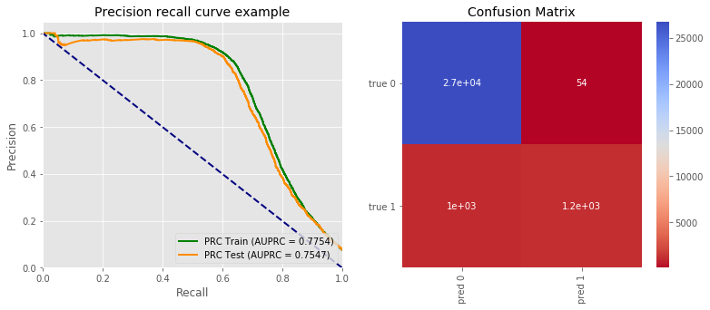

```python
# note that 'l1' does not give a converged coefficient
lr_param = {'C': 10,
           'penalty': 'l2'}
lr_clf = LogisticRegression(**lr_param)

train_test_model_AUPRC(lr_clf, X_train, y_train, X_test, y_test)
```

```python
# from sklearn.preprocessing import StandardScaler
# scaler = StandardScaler()
# scaler.fit(X_train)

# # note that 'l1' does not give a converged coefficient
# lr_param = {'C': 10,
#            'penalty': 'l1'}
# lr_clf = LogisticRegression(**lr_param)

# train_test_model_AUPRC(lr_clf,
#                        scaler.transform(X_train), y_train,
#                        scaler.transform(X_test), y_test)
```

#### Penalize Weights Algorithms (Cost-Sensitive Training)

```
Model fitting time is 7.74s
              train      test
metrics
AUPRC      0.731637  0.706132
Precision  0.417131  0.416145
Recall     0.807179  0.790389
f1-score   0.550023  0.545225
AUC        0.925520  0.920718
Accuracy   0.900613  0.900772
```

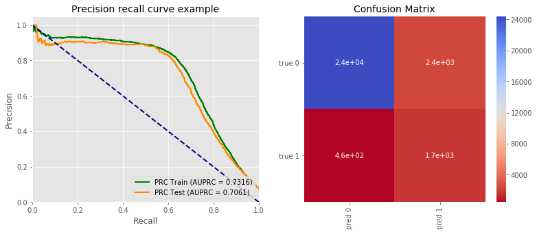

```python
# note that 'l1' does not give a converged coefficient
lr_param_weighted = {'C': 20,
            'penalty': 'l2',
            'class_weight': 'balanced'}
lr_clf_weighted = LogisticRegression(**lr_param_weighted)

train_test_model_AUPRC(lr_clf_weighted, X_train, y_train, X_test, y_test)
```

```python
lr_param_grid = {'C': [10, 20, 30, 40],
                 'penalty': ['l2'],
                 'class_weight':['balanced', None]
                }
lr_grid_clf = LogisticRegression()

lr_grid_obj = GridSearchCV(lr_grid_clf, lr_param_grid, cv=3, scoring='average_precision')
lr_grid_obj.fit(X_train, y_train)
lr_best_clf = lr_grid_obj.best_estimator_
lr_best_clf
```

```
LogisticRegression(C=20, class_weight=None, dual=False, fit_intercept=True,
          intercept_scaling=1, max_iter=100, multi_class='ovr', n_jobs=1,
          penalty='l2', random_state=None, solver='liblinear', tol=0.0001,
          verbose=0, warm_start=False)
```

```
Model fitting time is 9.11s
              train      test
metrics
AUPRC      0.743223  0.723316
Precision  0.968548  0.958801
Recall     0.471165  0.468650
f1-score   0.633940  0.629573
AUC        0.910981  0.906411
Accuracy   0.959052  0.958497
```

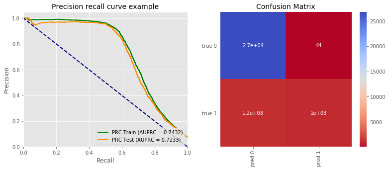

```python
train_test_model_AUPRC(lr_best_clf, X_train, y_train, X_test, y_test)
```

#### Make GridSearch Resampling Pipeline

If we want to implement cross validation, remember to oversample or undersample your training data during cross-validation, not before!

```python
# rus: random under sampler;  _rs: resampling

rs_seed = 901
# rs_method = RandomUnderSampler()
# rs_method = NearMiss(n_jobs=7)
rs_method = SMOTE(n_jobs=7, random_state=rs_seed)
# rs_method = SMOTEENN(n_jobs=7)
```

```python
lr_rs_clf = LogisticRegression()

# logistic regression pipeline: rsClf (resample + clf(classifier) )
lr_rsClf_pipeline = Pipeline([('rs_method', rs_method), ('lr_rs_clf', lr_rs_clf)])

rsClf_pipeline_param_grid = {'lr_rs_clf__C': [5, 10, 20, 30, 40],
                             'lr_rs_clf__penalty': ['l2']                            }

lr_grid_rs_obj = GridSearchCV(lr_rsClf_pipeline, rsClf_pipeline_param_grid, cv=3, scoring='average_precision')
lr_grid_rs_obj.fit(X_train, y_train)

lr_best_rsClf_pipeline = lr_grid_rs_obj.best_estimator_
lr_best_rsClf_pipeline
# lr_best_rsClf_pipeline.fit(X_train, y_train)
```

```
Pipeline(memory=None,
     steps=[('rs_method', SMOTE(k=None, k_neighbors=5, kind='regular', m=None, m_neighbors=10, n_jobs=7,
   out_step=0.5, random_state=901, ratio='auto', svm_estimator=None)), ('lr_rs_clf', LogisticRegression(C=5, class_weight=None, dual=False, fit_intercept=True,
          intercept_scaling=1, max_iter=100, multi_class='ovr', n_jobs=1,
          penalty='l2', random_state=None, solver='liblinear', tol=0.0001,
          verbose=0, warm_start=False))])
```

```
Model fitting time is 54.14s
              train      test
metrics
AUPRC      0.920359  0.915103
Precision  0.770877  0.765854
Recall     0.869164  0.862243
f1-score   0.817075  0.811195
AUC        0.977688  0.977499
Accuracy   0.970714  0.969794
```

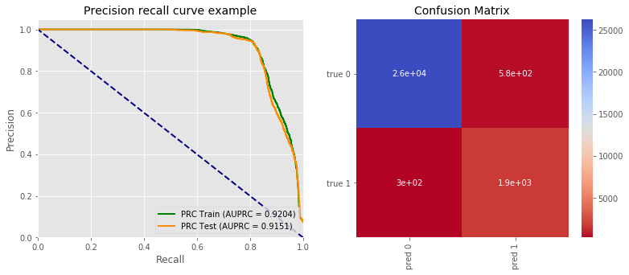

```python
train_test_model_AUPRC(lr_best_rsClf_pipeline, X_train, y_train, X_test, y_test)
```

### 2) Random Forest

```python
# Choose some parameter combinations to try
rf_param_grid = {'n_estimators': [50,100,200],
                 'max_features': ['auto'],
                 'criterion': ['gini'],
                 'max_depth': [5,10,15],
                 'random_state': [model_seed],
                 'min_samples_split': [2, 4, 6],
                 'min_samples_leaf': [2,10,20],
                 'n_jobs':[7],
                 'class_weight': [None, 'balanced']
                }
rf_grid_clf = RandomForestClassifier()

# Run the grid search
# read theory
rf_grid_obj = GridSearchCV(rf_grid_clf, rf_param_grid, cv=3, scoring='average_precision', n_jobs=7)
rf_grid_obj.fit(X_train, y_train)

# Set the clf to the best combination of parameters
rf_best_clf = rf_grid_obj.best_estimator_
rf_best_clf
```

```
RandomForestClassifier(bootstrap=True, class_weight=None, criterion='gini',
            max_depth=15, max_features='auto', max_leaf_nodes=None,
            min_impurity_decrease=0.0, min_impurity_split=None,
            min_samples_leaf=2, min_samples_split=6,
            min_weight_fraction_leaf=0.0, n_estimators=200, n_jobs=7,
            oob_score=False, random_state=101, verbose=0, warm_start=False)
```

```
Model fitting time is 50.80s
              train      test
metrics
AUPRC      0.953614  0.881364
Precision  0.999688  0.998495
Recall     0.629266  0.607323
f1-score   0.772361  0.755265
AUC        0.991353  0.951787
Accuracy   0.972087  0.970380
```

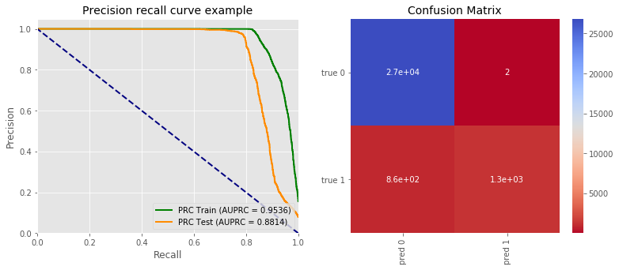

```python
train_test_model_AUPRC(rf_best_clf, X_train, y_train, X_test, y_test)
```

```python
rf_features = rf_best_clf.feature_importances_
```

```python
rf_best_clf
```

```
RandomForestClassifier(bootstrap=True, class_weight=None, criterion='gini',
            max_depth=15, max_features='auto', max_leaf_nodes=None,
            min_impurity_decrease=0.0, min_impurity_split=None,
            min_samples_leaf=2, min_samples_split=6,
            min_weight_fraction_leaf=0.0, n_estimators=200, n_jobs=7,
            oob_score=False, random_state=101, verbose=0, warm_start=False)
```

```
Model fitting time is 50.00s
              train      test
metrics
AUPRC      0.978962  0.875027
Precision  0.986178  0.962729
Recall     0.881718  0.768421
f1-score   0.931027  0.854670
AUC        0.997181  0.954592
Accuracy   0.990169  0.980333
```

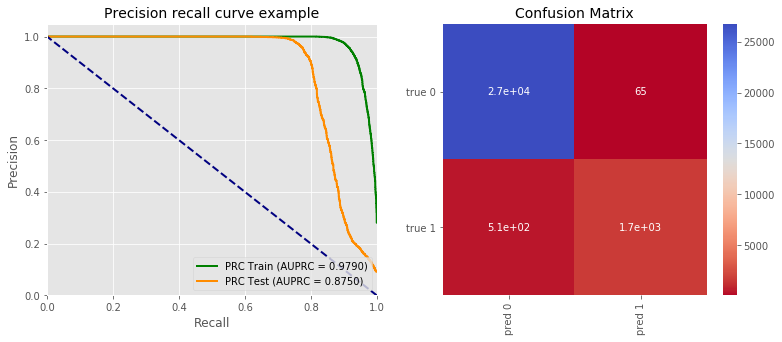

```python
# note that 'l1' does not give a converged coefficient
rf_param = {'n_estimators': 200,
            'max_features': 'auto',
            'criterion': 'gini',
            'max_depth': 15,
             'random_state': model_seed,
             'min_samples_split': 6,
             'min_samples_leaf': 2,
             'n_jobs': -1,
             'class_weight': 'balanced'}
rf_clf = RandomForestClassifier(**rf_param)

train_test_model_AUPRC(rf_clf, X_train, y_train, X_test, y_test)
```

#### Make GridSearch Resampling Pipeline

Tree-based models is somehow immune to imbalanced data.

For random forest, it seem SMOTE is not a effect method. One can refer to this [paper](https://bmcbioinformatics.biomedcentral.com/articles/10.1186/1471-2105-14-106).

```python
# rus: random under sampler;  _rs: resampling

rs_seed = 901
# rs_method = RandomUnderSampler()
# rs_method = NearMiss(n_jobs=7)
rf_rs_method = SMOTE(n_jobs=7, random_state=rs_seed)
# rs_method = SMOTEENN(n_jobs=7)
```

```python
# rf_rs_clf = RandomForestClassifier()

# # logistic regression pipeline: rsClf (resample + clf(classifier) )
# rf_rsClf_pipeline = Pipeline([('rf_rs_method', rs_method), ('rf_rs_clf', rf_rs_clf)])

# rsClf_pipeline_param_grid = {'rf_rs_clf__n_estimators': [50,100,200],
#                  'rf_rs_clf__max_features': ['auto'],
#                  'rf_rs_clf__criterion': ['gini'],
#                  'rf_rs_clf__max_depth': [5,10,15],
#                  'rf_rs_clf__random_state': [model_seed],
#                  'rf_rs_clf__min_samples_split': [2, 4, 6],
#                  'rf_rs_clf__min_samples_leaf': [2,10,20],
#                  'rf_rs_clf__n_jobs':[7]
#                 }
# rf_grid_rs_obj = GridSearchCV(rf_rsClf_pipeline, rsClf_pipeline_param_grid, cv=3, scoring='average_precision')
# rf_grid_rs_obj.fit(X_train, y_train)

# rf_best_rsClf_pipeline = rf_grid_rs_obj.best_estimator_
# rf_best_rsClf_pipeline
# # rf_best_rsClf_pipeline.fit(X_train, y_train)
```

```python
# train_test_model_AUPRC(rf_best_rsClf_pipeline, X_train, y_train, X_test, y_test)
```

### 3) GBDT

```python
# Choose some parameter combinations to try
gb_param_grid = {'n_estimators': [50,100],
                 'max_depth': [3, 4, 6],
                 'learning_rate': [.15, .1, .05],
                 'subsample': [0.8, 0.9],
                 'max_features': [0.8, 0.9],
                 'random_state': [model_seed]
                }
gb_grid_clf = GradientBoostingClassifier()

# Run the grid search
# read theory
gb_grid_obj = GridSearchCV(gb_grid_clf, gb_param_grid, cv=3, scoring='average_precision', n_jobs=7)
gb_grid_obj.fit(X_train, y_train)

# Set the clf to the best combination of parameters
gb_best_clf = gb_grid_obj.best_estimator_
gb_best_clf
```

```
GradientBoostingClassifier(criterion='friedman_mse', init=None,
              learning_rate=0.1, loss='deviance', max_depth=6,
              max_features=0.8, max_leaf_nodes=None,
              min_impurity_decrease=0.0, min_impurity_split=None,
              min_samples_leaf=1, min_samples_split=2,
              min_weight_fraction_leaf=0.0, n_estimators=100,
              presort='auto', random_state=101, subsample=0.9, verbose=0,
              warm_start=False)
```

```
Model fitting time is 127.89s
              train      test
metrics
AUPRC      0.967692  0.899866
Precision  0.996796  0.961262
Recall     0.854257  0.794966
f1-score   0.920038  0.870240
AUC        0.991252  0.970981
Accuracy   0.988826  0.982159
```

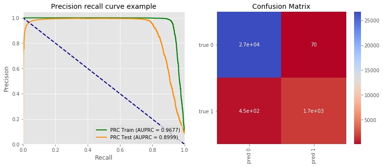

```python
train_test_model_AUPRC(gb_best_clf, X_train, y_train, X_test, y_test)
```

```python
gb_features = gb_best_clf.feature_importances_
```

```python
df_feature_importance = pd.DataFrame()
df_feature_importance['feature'] = X.columns.tolist()
df_feature_importance['gb_imp'] = gb_features
```

[figure not shown]

```python
plt.figure(figsize=(10,8))
sns.set_style('darkgrid')
sns.barplot(y = 'feature', x = 'gb_imp',
            data = df_feature_importance.sort_values('gb_imp', ascending = False).iloc[:20, ])
plt.title('Feature Importance Plot of Gradient Boosting')
plt.show()
```

```
Model fitting time is 68.62s
              train      test
metrics
AUPRC      0.937748  0.888833
Precision  0.994500  0.968592
Recall     0.815810  0.790389
f1-score   0.896336  0.870464
AUC        0.982134  0.968847
Accuracy   0.985800  0.982297
```

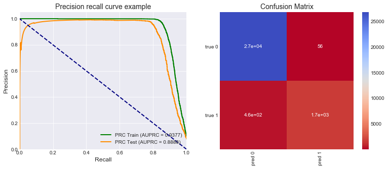

```python
# note that 'l1' does not give a converged coefficient
gb_param = {'n_estimators': 100,
            'max_depth': 4,
            'learning_rate': .15,
            'subsample': 0.9,
            'max_features': 0.9,
            'random_state': model_seed
           }
gb_clf = GradientBoostingClassifier(**gb_param)

train_test_model_AUPRC(gb_clf, X_train, y_train, X_test, y_test)
```

#### Make GridSearch Resampling Pipeline

```python
# rus: random under sampler;  _rs: resampling

rs_seed = 901
# rs_method = RandomUnderSampler()
# rs_method = NearMiss(n_jobs=7)
gb_rs_method = SMOTE(n_jobs=7, random_state=rs_seed)
# rs_method = SMOTEENN(n_jobs=7)
```

```python
gb_rs_clf = GradientBoostingClassifier()

# logistic regression pipeline: rsClf (resample + clf(classifier) )
gb_rsClf_pipeline = Pipeline([('gb_rs_method', gb_rs_method), ('gb_rs_clf', gb_rs_clf)])

rsClf_pipeline_param_grid = {'gb_rs_clf__n_estimators': [100],
                 'gb_rs_clf__max_depth': [4],
                 'gb_rs_clf__learning_rate': [.15],
                 'gb_rs_clf__subsample': [0.9],
                 'gb_rs_clf__max_features': [0.9],
                 'gb_rs_clf__random_state': [model_seed]
                }
gb_grid_rs_obj = GridSearchCV(gb_rsClf_pipeline, rsClf_pipeline_param_grid, cv=3, scoring='average_precision')
gb_grid_rs_obj.fit(X_train, y_train)

gb_best_rsClf_pipeline = gb_grid_rs_obj.best_estimator_
gb_best_rsClf_pipeline
# gb_best_rsClf_pipeline.fit(X_train, y_train)
```

```
Pipeline(memory=None,
     steps=[('gb_rs_method', SMOTE(k=None, k_neighbors=5, kind='regular', m=None, m_neighbors=10, n_jobs=7,
   out_step=0.5, random_state=901, ratio='auto', svm_estimator=None)), ('gb_rs_clf', GradientBoostingClassifier(criterion='friedman_mse', init=None,
              learning_rate=0.15, loss='deviance...       presort='auto', random_state=101, subsample=0.9, verbose=0,
              warm_start=False))])
```

```
Model fitting time is 244.09s
              train      test
metrics
AUPRC      0.925427  0.891945
Precision  0.994161  0.970421
Recall     0.801491  0.780778
f1-score   0.887489  0.865331
AUC        0.978799  0.966425
Accuracy   0.984707  0.981711
```

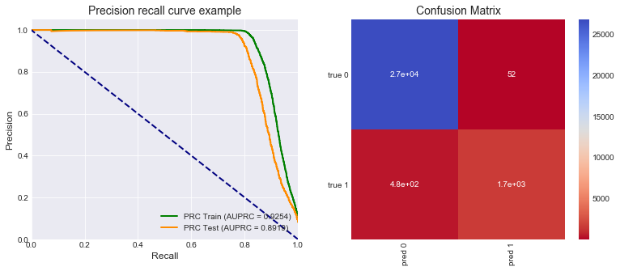

```python
train_test_model_AUPRC(gb_best_rsClf_pipeline, X_train, y_train, X_test, y_test)
```

### 4) XGBoost

```python
pos_weight = y.value_counts().iloc[0, ]/y.value_counts().iloc[1, ]
```

```python
# Choose some parameter combinations to try
xgb_param_grid = {'n_estimators': [100, 150],
                 'max_depth': [4, 6],
                 'learning_rate': [.1, .15, 2],
                 'subsample': [.8, .9],
                 'colsample_bytree': [.2, .5, .8],
                 'n_jobs': [7],
                 'seed': [model_seed],
                 'scale_pos_weight': [1]
                 }
xgb_grid_clf = XGBClassifier()

# Run the grid search
# read theory
xgb_grid_obj = GridSearchCV(xgb_grid_clf, xgb_param_grid, cv=3, scoring='average_precision', n_jobs=7)
xgb_grid_obj.fit(X_xgb_train, y_xgb_train)

# Set the clf to the best combination of parameters
xgb_best_clf = xgb_grid_obj.best_estimator_
xgb_best_clf
```

```
XGBClassifier(base_score=0.5, booster='gbtree', colsample_bylevel=1,
       colsample_bytree=0.5, gamma=0, learning_rate=0.15, max_delta_step=0,
       max_depth=6, min_child_weight=1, missing=None, n_estimators=150,
       n_jobs=7, nthread=None, objective='binary:logistic', random_state=0,
       reg_alpha=0, reg_lambda=1, scale_pos_weight=1, seed=101,
       silent=True, subsample=0.9)
```

```python
cross_val_score(xgb_best_clf, X_xgb_train, y_xgb_train,
                cv=3, scoring='average_precision', n_jobs=-1).mean()
```

```
0.9193228703718347
```

```python
pos_weight
```

```
12.288342715913771
```

```python
xgb_man_param = {
    'n_estimators': 150,
    'max_depth': 6,
    'learning_rate': .2,
    'subsample': .9,
    'colsample_bytree': .5,
    'n_jobs': 7,
    'seed': model_seed,
    'scale_pos_weight': pos_weight/2
    # ,  'scale_pos_weight': pos_weight
}

xgb_man_clf = XGBClassifier(**xgb_man_param)
cross_val_score(xgb_man_clf, X_xgb_train, y_xgb_train,
                cv=3, scoring='average_precision', n_jobs=-1).mean()
```

```
0.9165150562309482
```

```
Model fitting time is 72.80s
```

```
              train      test
metrics
AUPRC      0.999803  0.921111
Precision  0.992773  0.945932
Recall     0.997058  0.824714
f1-score   0.994911  0.881174
AUC        0.999984  0.976487
Accuracy   0.999232  0.983261
```

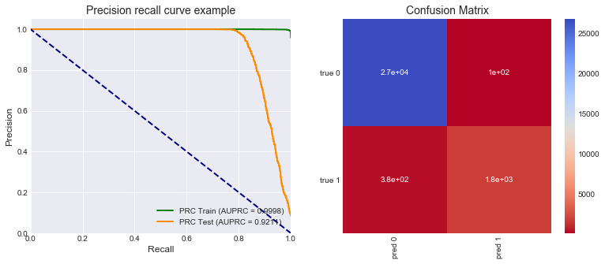

```python
train_test_model_AUPRC(xgb_man_clf, X_xgb_train, y_xgb_train, X_xgb_test, y_xgb_test)
```

#### The following the is the best precision-driven model.

```
Model fitting time is 73.07s
```

```
              train      test
metrics
AUPRC      0.996196  0.924100
Precision  0.999555  0.980942
Recall     0.882111  0.800915
f1-score   0.937168  0.881834
AUC        0.999544  0.977925
Accuracy   0.991099  0.983847
```

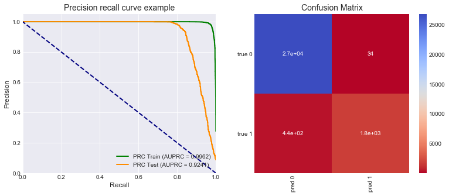

```python
train_test_model_AUPRC(xgb_best_clf, X_xgb_train, y_xgb_train, X_xgb_test, y_xgb_test)
```

#### Feature Importance

```python
xgb_features = xgb_best_clf.feature_importances_
```

```python
df_feature_importance['xgb_imp'] = xgb_features
```

[figure not shown]

```python
plt.figure(figsize=(10,8))
sns.set_style('darkgrid')
sns.barplot(y = 'feature', x = 'xgb_imp',
            data = df_feature_importance.sort_values('xgb_imp', ascending = False).iloc[:20, ])
plt.title('Feature Importance Plot of XGBoost')
plt.show()
```

```
Model fitting time is 120.02s
```

```
              train      test
metrics
AUPRC      0.986281  0.921133
Precision  0.998609  0.985779
Recall     0.844645  0.793135
f1-score   0.915197  0.879026
AUC        0.998040  0.976489
Accuracy   0.988221  0.983571
```

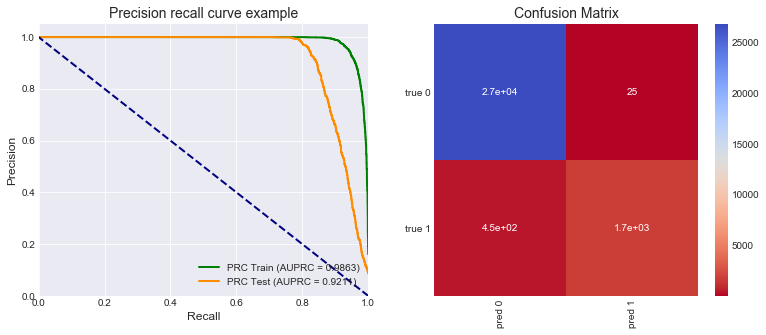

```python
xgb_param = {'n_estimators': 150,
             'max_depth': 6,
             'learning_rate': .1,
             'subsample': .9,
             'colsample_bytree': .8,
             'n_jobs': -1,
             'seed': model_seed,
             'scale_pos_weight': 1}
xgb_clf = XGBClassifier(**xgb_param)

train_test_model_AUPRC(xgb_clf, X_xgb_train, y_xgb_train, X_xgb_test, y_xgb_test)
```

```python
# rus: random under sampler;  _rs: resampling

rs_seed = 901
# rs_method = RandomUnderSampler()
# rs_method = NearMiss(n_jobs=7)
xgb_rs_method = SMOTE(n_jobs=7, random_state=rs_seed)
# rs_method = SMOTEENN(n_jobs=7)
```

```python
# xgb_rs_clf = XGBClassifier()

# # logistic regression pipeline: rsClf (resample + clf(classifier) )
# xgb_rsClf_pipeline = Pipeline([('xgb_rs_method', xgb_rs_method), ('xgb_rs_clf', xgb_rs_clf)])

# rsClf_pipeline_param_grid = {'xgb_rs_clf__n_estimators': [150],
#                              'xgb_rs_clf__max_depth': [6],
#                              'xgb_rs_clf__learning_rate': [.1],
#                              'xgb_rs_clf__subsample': [.9],
#                              'xgb_rs_clf__colsample_bytree': [.8],
#                              'xgb_rs_clf__n_jobs': [7],
#                              'xgb_rs_clf__seed': [model_seed],
#                              'xgb_rs_clf__scale_pos_weight': [1]
#                              }
# xgb_grid_rs_obj = GridSearchCV(xgb_rsClf_pipeline, rsClf_pipeline_param_grid, cv=3, scoring='average_precision')
# xgb_grid_rs_obj.fit(X_xgb_train, y_xgb_train)

# xgb_best_rsClf_pipeline = xgb_grid_rs_obj.best_estimator_
# xgb_best_rsClf_pipeline
# # xgb_best_rsClf_pipeline.fit(X_train, y_train)
```

```python
# train_test_model_AUPRC(xgb_best_rsClf_pipeline, X_xgb_train, y_xgb_train, X_xgb_test, y_xgb_test)
```

```python
X_xgb_rs_train, y_xgb_rs_train = xgb_rs_method.fit_sample(X_xgb_train, y_xgb_train)
```

#### However, if we employ the SMOTE before the XGBoost, the model does not improve somehow.

```python
# Choose some parameter combinations to try
xgb_rs_param_grid = {'n_estimators': [100, 150],
                 'max_depth': [4, 6],
                 'learning_rate': [.1, .15, 2],
                 'subsample': [.8, .9],
                 'colsample_bytree': [.2, .5, .8],
                 'n_jobs': [7],
                 'seed': [model_seed],
                 'scale_pos_weight': [1]
                 }
xgb_rs_grid_clf = XGBClassifier()

# Run the grid search
# read theory
xgb_rs_grid_obj = GridSearchCV(xgb_rs_grid_clf, xgb_rs_param_grid, cv=3, scoring='average_precision', n_jobs=7)
xgb_rs_grid_obj.fit(pd.DataFrame(X_xgb_rs_train), y_xgb_rs_train)

# Set the clf to the best combination of parameters
xgb_rs_best_clf = xgb_rs_grid_obj.best_estimator_
xgb_rs_best_clf
```

```
XGBClassifier(base_score=0.5, booster='gbtree', colsample_bylevel=1,
       colsample_bytree=0.8, gamma=0, learning_rate=0.1, max_delta_step=0,
       max_depth=6, min_child_weight=1, missing=None, n_estimators=150,
       n_jobs=7, nthread=None, objective='binary:logistic', random_state=0,
       reg_alpha=0, reg_lambda=1, scale_pos_weight=1, seed=101,
       silent=True, subsample=0.8)
```

```python
cross_val_score(xgb_rs_best_clf, X_xgb_rs_train, y_xgb_rs_train,
                cv=3, scoring='average_precision', n_jobs=-1).mean()
```

```
0.9971675228670517
```

```python
xgb_rs_man_param = {
    'n_estimators': 150,
    'max_depth': 6,
    'learning_rate': .1,
    'subsample': .8,
    'colsample_bytree': .8,
    'n_jobs': 7,
    'seed': model_seed,
    'scale_pos_weight': 1
    # ,  'scale_pos_weight': pos_weight
}

xgb_rs_man_clf = XGBClassifier(**xgb_rs_man_param)
cross_val_score(xgb_rs_man_clf, X_xgb_rs_train, y_xgb_rs_train,
                cv=3, scoring='average_precision', n_jobs=-1).mean()
```

```
0.9971675228670517
```

```
Model fitting time is 104.63s
```

```
              train      test
metrics
AUPRC      0.985149  0.921062
Precision  0.998612  0.981900
Recall     0.846607  0.794508
f1-score   0.916348  0.878320
AUC        0.997937  0.976981
Accuracy   0.988368  0.983433
```

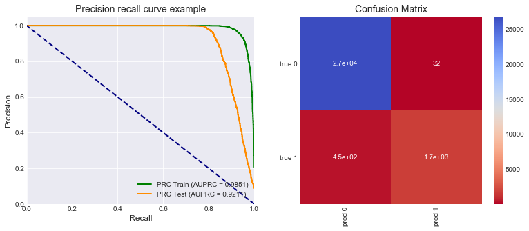

```python
train_test_model_AUPRC(xgb_rs_man_clf, X_xgb_train, y_xgb_train, X_xgb_test, y_xgb_test)
```